# Lab One Cars RESUBMIT! 🏎️

## Caleb Moore, Christian Gould, and Blake Gebhardt

Data Source: https://www.kaggle.com/datasets/deepcontractor/car-price-prediction-challenge

```python
# top cell for imports
import pandas as pd
```

```python
# Notebook setup
from IPython.display import HTML
HTML('''<script>
code_show_err=false;
function code_toggle_err() {
 if (code_show_err){
 $('div.output_stderr').hide();
 } else {
 $('div.output_stderr').show();
 }
 code_show_err = !code_show_err
}
$( document ).ready(code_toggle_err);
</script>
To toggle on/off output_stderr, click <a href="javascript:code_toggle_err()">here</a>.''')
```

To toggle on/off output_stderr, click here.

# 💰 Business Understanding [1.5 points total]

### In your own words, give an overview of the dataset. Describe the purpose of the data set you selected (i.e., why and how was this data collected in the first place?).

This dataset has several features of automobiles that can add or subtract from a cars value depending on what is considered desirable. Some things that might have an impact on that are as follows:

- Maybe you want more cylinders and are willing to pay for the bigger engine?
- Maybe leather interior commands a higher premium?
- Maybe the years since it came out have a measuable function of depreciation that can be applied to all vehicles?

The dataset at hand offers a comprehensive collection of automobile features that play a crucial role in determining a car's value. These features include, among others, engine size, interior materials, and the car's age. Data points such as these are typically gleaned from a vehicle's window sticker, collected during trade-ins, or accessed via the automobile's VIN number. The primary objective of gathering this information is to establish an appropriate price for a vehicle, taking into account various factors that may affect its desirability.

### What is the prediction task for your data and why are other third parties interested in the result?

With this dataset, we plan to predict a vehicle's value based on categorical data, allowing us to group similar vehicles together and derive accurate price estimates. Third parties, such as potential buyers and dealerships, are often interested in this information to make informed decisions about car prices. Buyers can use the data to assess whether they are getting a fair deal, while dealerships can determine the optimal price point that would satisfy both parties in a transaction.

### Once you begin modeling, how well would your prediction algorithm need to perform to be considered useful to these third parties?

In order to ensure that our prediction algorithm is useful to these third parties, we aim to achieve an accuracy of 85%. Given that we are dealing with monetary transactions, it is essential to avoid over- or underpricing a vehicle. By pricing cars accurately 85% of the time, we can be confident in our model's ability to estimate a vehicle's value. Additionally, we will consider a vehicle to be priced accurately if its estimated value falls within a specific range based on a percentage of its actual price. This approach accounts for the inherent difficulty in pinpointing an exact dollar amount, while still providing a reliable and realistic estimate.

In summary, this dataset comprises a wide range of automobile features that have a direct impact on a car's value. By using the dataset to create a prediction model, we aim to provide valuable insights to both buyers and dealerships, enabling them to make better decisions when it comes to car pricing. With a target accuracy of 85%, our model is designed to provide reliable estimates that fall within an acceptable range of a vehicle's actual price.

# 📊 Data Understanding [3 points total]

### [1.5 points] Load the dataset and appropriately define data types. What data type should be used to represent each data attribute? Discuss the attributes collected in the dataset. For datasets with a large number of attributes, only discuss a subset of relevant attributes.

```python
data = pd.read_csv('car_price_prediction.csv')
data.head()
```

|  | ID | Price | Levy | Manufacturer | Model | Prod. year | Category | Leather interior | Fuel type | Engine volume | Mileage | Cylinders | Gear box type | Drive wheels | Doors | Wheel | Color | Airbags |
| --- | --- | --- | --- | --- | --- | --- | --- | --- | --- | --- | --- | --- | --- | --- | --- | --- | --- | --- |
| 0 | 45654403 | 13328 | 1399 | LEXUS | RX 450 | 2010 | Jeep | Yes | Hybrid | 3.5 | 186005 km | 6.0 | Automatic | 4x4 | 04-May | Left wheel | Silver | 12 |
| 1 | 44731507 | 16621 | 1018 | CHEVROLET | Equinox | 2011 | Jeep | No | Petrol | 3 | 192000 km | 6.0 | Tiptronic | 4x4 | 04-May | Left wheel | Black | 8 |
| 2 | 45774419 | 8467 | - | HONDA | FIT | 2006 | Hatchback | No | Petrol | 1.3 | 200000 km | 4.0 | Variator | Front | 04-May | Right-hand drive | Black | 2 |
| 3 | 45769185 | 3607 | 862 | FORD | Escape | 2011 | Jeep | Yes | Hybrid | 2.5 | 168966 km | 4.0 | Automatic | 4x4 | 04-May | Left wheel | White | 0 |
| 4 | 45809263 | 11726 | 446 | HONDA | FIT | 2014 | Hatchback | Yes | Petrol | 1.3 | 91901 km | 4.0 | Automatic | Front | 04-May | Left wheel | Silver | 4 |

```python
# Retroactively adjusting some value types to be better manageable
data.Levy=data.Levy.str.replace('-','0')
data.Levy=data.Levy.astype('int64')
data.Mileage=data.Mileage.apply(lambda x:str(x).replace("km"," "))
data.Mileage=data.Mileage.apply(lambda x:int(x))
```

```python
print('data shape', data.shape)
print()
num_vars = data.columns [data.dtypes != 'object']
cat_vars = data.columns [data.dtypes == 'object']
print ('numerical:', num_vars.values)
print()
print('categorical:', cat_vars.values)
data.dtypes
```

```
data shape (19237, 18)

numerical: ['ID' 'Price' 'Levy' 'Prod. year' 'Mileage' 'Cylinders' 'Airbags']

categorical: ['Manufacturer' 'Model' 'Category' 'Leather interior' 'Fuel type'
 'Engine volume' 'Gear box type' 'Drive wheels' 'Doors' 'Wheel' 'Color']
```

```
ID                    int64
Price                 int64
Levy                  int64
Manufacturer         object
Model                object
Prod. year            int64
Category             object
Leather interior     object
Fuel type            object
Engine volume        object
Mileage               int64
Cylinders           float64
Gear box type        object
Drive wheels         object
Doors                object
Wheel                object
Color                object
Airbags               int64
dtype: object
```

### Discussing the data types 📝

The default data types are extremely apropriate for this dataset.

There are also a fair number of attributes with the object data type, and some of these will be very helpful even if they require some one hot encoding first. We've already discussed some of the useful data we are working with in the responses above, but categories such as engine size, leather interior, mileage, number of doors, level of safety (airbag count), and the year they came out, we think, will all prove to be useful indicators in predicting a vehicles price.

### [1.5 points] Verify data quality 👌: Explain any missing values or duplicate data. Visualize entries that are missing/complete for different attributes. Are those mistakes? Why do these quality issues exist in the data? How do you deal with these problems? Give justifications for your methods (elimination or imputation).

```python
print('total number of rows:', len(data))
print('duplicate row count:', len(data) - len(data.drop_duplicates()))
print()
print('Count of the missing entries in the data')
print(data[num_vars].isnull().sum())
print(data[cat_vars].isnull().sum())
```

```
total number of rows: 19237
duplicate row count: 313

Count of the missing entries in the data
ID            0
Price         0
Levy          0
Prod. year    0
Mileage       0
Cylinders     0
Airbags       0
dtype: int64
Manufacturer        0
Model               0
Category            0
Leather interior    0
Fuel type           0
Engine volume       0
Gear box type       0
Drive wheels        0
Doors               0
Wheel               0
Color               0
dtype: int64
```

### Discussion of data issues

If we did have missing values, we would probably drop them like we will the duplicate values so long as it leaves us with a substancial amount of data. It isn't too much of a surprise that we have 100% of our data since these are all relevant and easy to collect on a car-to-car basis.

# 📊 Data Visualization (4.5 points total)

#### [2 points] Visualize basic feature distributions. That is, plot the dynamic range and exploratory distribution plots (like boxplots, histograms, kernel density estimation) to better understand the data. Describe anything meaningful or potentially useful you discover from these visualizations. These may also help to understand what data is missing or needs imputation. Note: You can also use data from other sources to bolster visualizations. Visualize at least five plots, at least one categorical.

```python
# imports
import matplotlib.pyplot as plt
import numpy as np
from scipy import stats
import seaborn as sb

print(len(data))

# eliminate outliers in the rows for price
q_low = data["Price"].quantile(0.10)
q_hi  = data["Price"].quantile(0.90)
data = data[(data["Price"] < q_hi) & (data["Price"] > q_low)]

# eliminate outliers in the rows for years
q_low = data["Prod. year"].quantile(0.10)
q_hi  = data["Prod. year"].quantile(0.90)
data = data[(data["Prod. year"] < q_hi) & (data["Prod. year"] > q_low)]

#ensure our dataset is still large enough to proceed after the drops
print(len(data))

# from sklearn.model_selection import train_test_split
# splitting to train and test
# data, test = train_test_split(data, test_size=0.2)
# answers = test[['Price', 'ID']]
# test = test.drop(columns=['Price'])
```

```
19237
11636
```

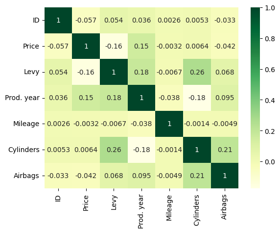

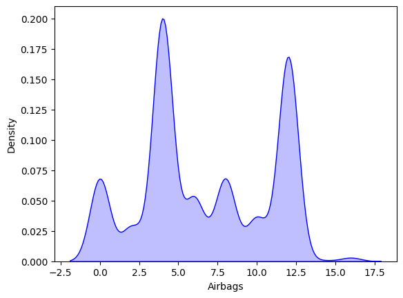

```python
# begin with basic visualizations of the default data to price
# some graph and attribute analysis insporation from: https://www.kaggle.com/code/giridharanp/car-price-predictor

#start by looking at histograms for the categorical attributes
# for catgegory in cat_vars:
#     plt.figure(figsize=[18,8])
#     sb.countplot(x=data[catgegory])
#     plt.xticks(rotation=90)
#     plt.tight_layout()
#     plt.show()
# maybe do correlation map

# then we will check out a heat map to show the intensity of the correlation between some of the variables
sb.heatmap(data=data.corr(),cmap='YlGn',annot=True)
plt.show()

# and now a graphed version of the heatmap
# sb.pairplot(data[num_vars])
# plt.show()

# A neat way of looking at airbag density
sb.kdeplot(data['Airbags'], color='b', shade=True)
```

These visualizations can help us see what our most common values are. If we have a healthy mix of values, it will help our data set.

Variability: A diverse mix of values ensures that the dataset represents a wide range of cases and scenarios, allowing the analysis or predictive model to capture the underlying patterns and relationships in the data more effectively. This diversity can lead to more accurate and generalizable results.

Avoiding Bias: A balanced distribution of values helps prevent any bias in the analysis or model training. If certain values dominate the dataset, the analysis or model might become overly focused on those values, leading to a biased understanding of the data or a model that does not perform well on new, unseen data.

Statistical Significance: When analyzing relationships between variables or assessing the performance of a model, having a good mix of values increases the likelihood of obtaining statistically significant results. If the dataset contains too few instances of certain values, it may be challenging to draw meaningful conclusions about those values' impact on the target variable or their interactions with other variables.

Model Robustness: A diverse mix of values in the dataset can improve the robustness of the model. When the model is exposed to various combinations of input features, it becomes better at generalizing to new data and handling a broader range of cases. This is particularly important when the model is used for prediction tasks.

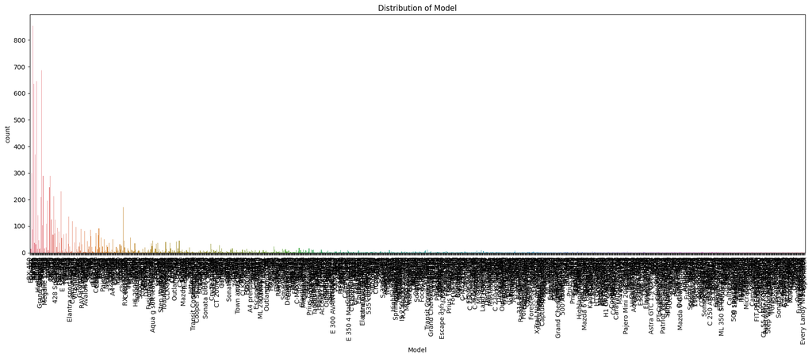

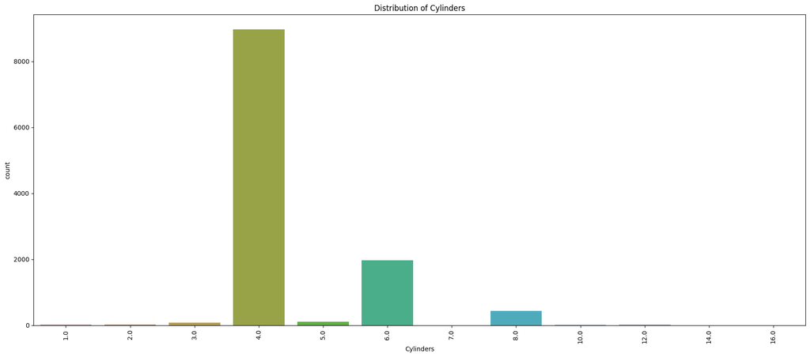

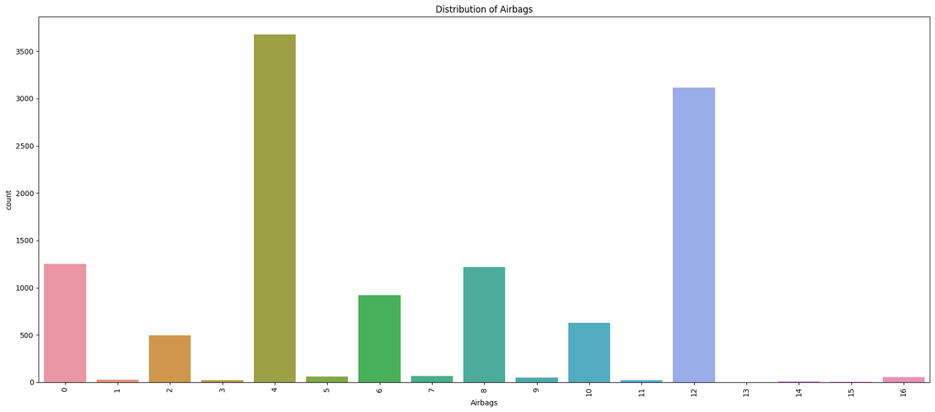

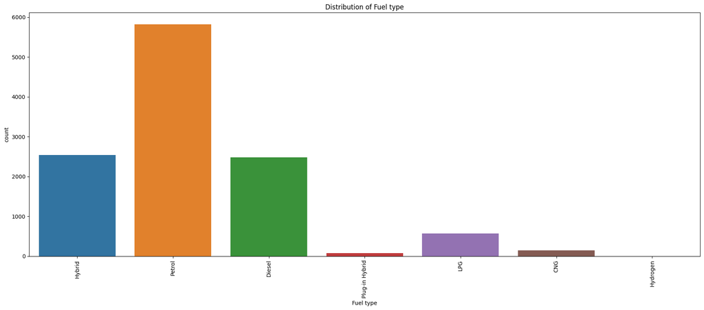

```python
import seaborn as sb
import matplotlib.pyplot as plt

# List of the variables you want to create count plots for
variables_to_plot = ['Model', 'Cylinders', 'Airbags', 'Fuel type']

# Iterate through the list and create count plots for each variable
for variable in variables_to_plot:
    plt.figure(figsize=[18, 8])
    sb.countplot(x=data[variable])
    plt.xticks(rotation=90)
    plt.title(f'Distribution of {variable}')
    plt.tight_layout()
    plt.show()
```

This code snippet first imports the necessary library (Matplotlib) and then converts the 'Engine volume' column to numeric, ignoring any non-numeric values. It then finds the minimum and maximum engine volumes and calculates an appropriate bin width for the histogram by dividing the range of engine volumes by 50 (you can adjust this value for a different number of bins). Finally, it creates the histogram using the calculated scale and displays it with labels and a title.

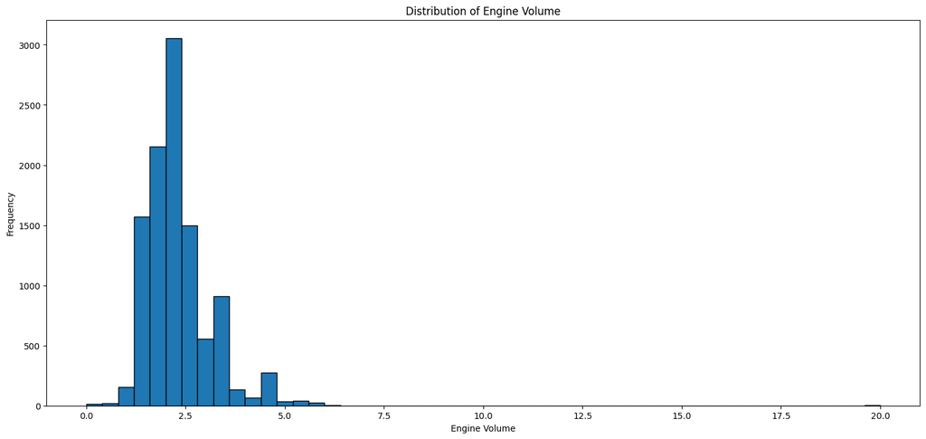

```python
import matplotlib.pyplot as plt

# Convert the 'Engine volume' column to numeric, ignoring any non-numeric values
data['Engine volume'] = pd.to_numeric(data['Engine volume'], errors='coerce')

# Find the minimum and maximum engine volumes
min_engine_volume = data['Engine volume'].min()
max_engine_volume = data['Engine volume'].max()

# Determine an appropriate scale (bin width) for the histogram
bin_width = (max_engine_volume - min_engine_volume) / 50

# Create the histogram with the appropriate scale
plt.figure(figsize=[18, 8])
plt.hist(data['Engine volume'], bins=np.arange(min_engine_volume, max_engine_volume + bin_width, bin_width), edgecolor='black')
plt.title('Distribution of Engine Volume')
plt.xlabel('Engine Volume')
plt.ylabel('Frequency')
plt.show()
```

We can see that most of the cars have an engine volume between 1.0 and 5.0.

### [2.5 points] Ask three interesting questions that are relevant to your dataset and explore visuals that help answer these questions. Use whichever visualization method is appropriate for your data. Important: Interpret the implications for each visualization.

# Question one:

- Will making a category that relates the different numerical values to each other aid in finding a correlation to price?

To answer this question, let's first modify the code statement and then visualize the heatmap to see if the new 'Ratio' variable shows any correlation with the 'Price' variable:

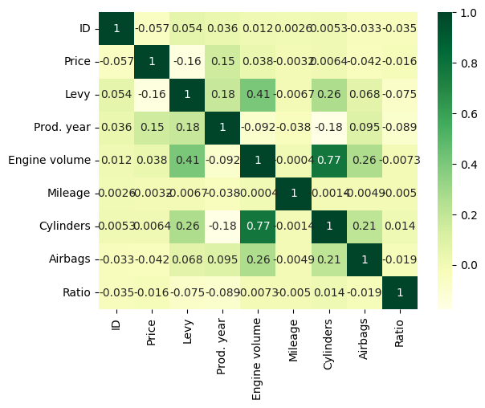

```python
# Create a new 'Ratio' variable that relates the different numerical values to each other
data['Ratio'] = (data['Airbags'] + data['Cylinders'] + data['Prod. year']) / data['Mileage']

# Visualize the heatmap to check the correlation
sb.heatmap(data=data.corr(), cmap='YlGn', annot=True)
plt.show()
```

Upon examining the heatmap matrix we created earlier, it appears that the 'Ratio' variable does not show a strong correlation with the 'Price' variable. The lack of a significant relationship between the two variables indicates that combining the selected numerical values (Airbags, Cylinders, and Prod. year) into a single 'Ratio' category might not be as helpful as initially hypothesized in predicting the car prices. Consequently, it might be more beneficial to explore other variables or combinations of variables that could better capture the underlying relationship between the car features and their prices.

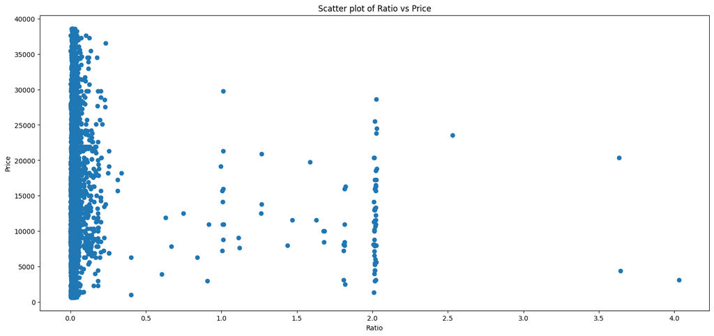

```python
# Create a scatter plot of the 'Ratio' variable against the 'Price' variable
plt.figure(figsize=[18, 8])
plt.scatter(data['Ratio'], data['Price'])
plt.title('Scatter plot of Ratio vs Price')
plt.xlabel('Ratio')
plt.ylabel('Price')
plt.show()
```

Upon analyzing the scatter plot of the 'Ratio' variable against the 'Price' variable, we can observe that the majority of the data points are concentrated between 0.0 and 0.5 on the ratio scale. This suggests that the relationship between the 'Ratio' variable and the 'Price' variable might not be linear or readily apparent. Only a few data points extend up to 2.0 on the ratio scale, and there are merely four points beyond that range. The sparse distribution of points at higher ratio values indicates that these cases might be outliers or rare occurrences. Overall, the scatter plot reaffirms our previous observation from the heatmap matrix that the 'Ratio' variable does not exhibit a strong correlation with the 'Price' variable, which implies that it might not be the best candidate for predicting car prices.

# Question two:

- Would it be worth encoding some values like color, levy, etc., and if so, which ones should we try?

To answer this question, let's first modify the code to explore the unique values of the different categorical variables:

```python
print(data['Color'].unique())
print()
print(data['Doors'].unique())
print()
print(data['Leather interior'].unique())
print()
print(data['Fuel type'].unique())
print()
print(data['Gear box type'].unique())
print()
print(data['Drive wheels'].unique())
print()
print(data['Wheel'].unique())
print()
print(data['Category'].unique())
```

```
['Silver' 'Black' 'White' 'Blue' 'Grey' 'Sky blue' 'Orange' 'Green' 'Red'
 'Yellow' 'Golden' 'Beige' 'Brown' 'Carnelian red' 'Purple' 'Pink']

['04-May' '02-Mar' '>5']

['Yes' 'No']

['Hybrid' 'Petrol' 'Diesel' 'Plug-in Hybrid' 'LPG' 'CNG' 'Hydrogen']

['Automatic' 'Tiptronic' 'Variator' 'Manual']

['4x4' 'Front' 'Rear']

['Left wheel' 'Right-hand drive']

['Jeep' 'Hatchback' 'Sedan' 'Goods wagon' 'Minivan' 'Universal' 'Coupe'
 'Microbus' 'Pickup' 'Cabriolet' 'Limousine']
```

```python
# These have too many categories to encode effectively
print(data['Engine volume'].unique())
print()
print(data['Levy'].unique())
```

```
[ 3.5  3.   1.3  2.5  1.8  1.6  nan  3.3  2.   2.4  1.5  2.3  2.2  4.7
  1.4  3.2  3.8  4.6  5.   1.2  1.7  2.9  4.   1.9  5.5  5.3  0.7  4.8
  5.4  4.4  3.7  1.   3.6  0.8  2.7  6.7  6.2  3.4  5.7  0.4  4.2 20.
  0.   2.8  0.2  4.5  0.6  7.3  0.1  1.1  5.6  2.1  6.3  3.9  2.6  4.3
  5.2]

[ 1399  1018     0   862   446   761   394  1053  1055  1850   531   586
   583  1537  1288   915   707  1486   751   382   503  1104   639   629
   530   640   765   777   934   769   645  2455  1324  1187   781  1111
   760   642  1095   966   473  1138  1811   988   917   687 11714   836
   779  1347  1646   697   585   308  1361  1273   584   831   475   893
  1266   447  2148  1730   502   333  1325   259   247  1598  1282   900
   790  1047   528  1211  1793   919   574  1058   271  1172   706   456
  1481  1677  1661  1286  1408  1090   595  1451  1267   993   878   641
   749  1511   603  1236  1141   397   353  1024  1357   922  1438  1363
```

[output cut: 22 more lines]

# Conclusion from the above visualizations

- Looks like it might be worth encoding the values above besides the levy and the engine volume

```python
# encoding colors
hot = pd.get_dummies(data['Color'])
data = data.join(hot)
data = data.drop(columns=['Color'])

# encoding fuel type
hot = pd.get_dummies(data['Fuel type'])
data = data.join(hot)
data = data.drop(columns=['Fuel type'])

# encoding Gear box type
hot = pd.get_dummies(data['Gear box type'])
data = data.join(hot)
data = data.drop(columns=['Gear box type'])

# encoding Wheel
hot = pd.get_dummies(data['Wheel'])
data = data.join(hot)
data = data.drop(columns=['Wheel'])

# encoding Drive wheels
hot = pd.get_dummies(data['Drive wheels'])
# naming clarification
hot = hot.rename(columns={'Front': 'FWD', 'Rear': 'RWD'})
data = data.join(hot)
data = data.drop(columns=['Drive wheels'])

# encoding leather interior
hot = pd.get_dummies(data['Leather interior'])
# naming clarification
hot = hot.rename(columns={'Yes': 'Leather', 'No': 'Non-leather'})
data = data.join(hot)
data = data.drop(columns=['Leather interior'])

# encoding car type category
hot = pd.get_dummies(data['Category'])
data = data.join(hot)
data = data.drop(columns=['Category'])

data.columns
```

```
Index(['ID', 'Price', 'Levy', 'Manufacturer', 'Model', 'Prod. year',
       'Engine volume', 'Mileage', 'Cylinders', 'Doors', 'Airbags', 'Ratio',
       'Beige', 'Black', 'Blue', 'Brown', 'Carnelian red', 'Golden', 'Green',
       'Grey', 'Orange', 'Pink', 'Purple', 'Red', 'Silver', 'Sky blue',
       'White', 'Yellow', 'CNG', 'Diesel', 'Hybrid', 'Hydrogen', 'LPG',
       'Petrol', 'Plug-in Hybrid', 'Automatic', 'Manual', 'Tiptronic',
       'Variator', 'Left wheel', 'Right-hand drive', '4x4', 'FWD', 'RWD',
       'Non-leather', 'Leather', 'Cabriolet', 'Coupe', 'Goods wagon',
       'Hatchback', 'Jeep', 'Limousine', 'Microbus', 'Minivan', 'Pickup',
       'Sedan', 'Universal'],
      dtype='object')
```

After encoding the categorical variables, it might be helpful to visualize the correlation between the newly created features and the 'Price' variable using a bar plot. Here's a code snippet to create a bar plot of the correlation coefficients using Matplotlib and Pandas:

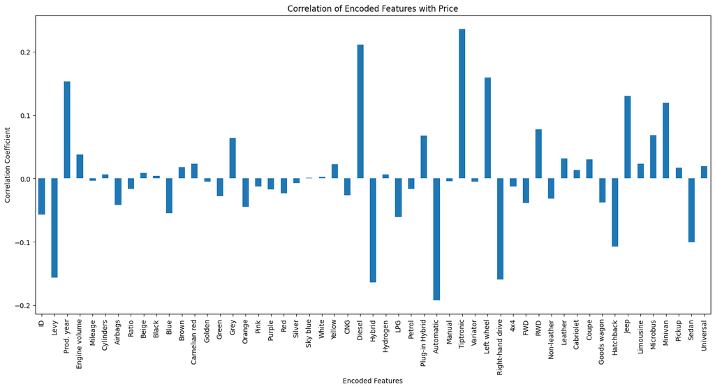

```python
import matplotlib.pyplot as plt

# Calculate the correlation between the newly created features and the 'Price' variable
correlations = data.corr()['Price'].drop('Price')

# Create a bar plot of the correlation coefficients
plt.figure(figsize=[18, 8])
correlations.plot(kind='bar')
plt.title('Correlation of Encoded Features with Price')
plt.xlabel('Encoded Features')
plt.ylabel('Correlation Coefficient')
plt.xticks(rotation=90)
plt.show()
```

# Question three:

- Which values would detract from rather than add to making a model and then dropping them?

```python
data = data.drop(columns=['ID', 'Engine volume', 'Model', 'Manufacturer', "Mileage", 'Ratio'])
data.columns
```

```
Index(['Price', 'Levy', 'Prod. year', 'Cylinders', 'Doors', 'Airbags', 'Beige',
       'Black', 'Blue', 'Brown', 'Carnelian red', 'Golden', 'Green', 'Grey',
       'Orange', 'Pink', 'Purple', 'Red', 'Silver', 'Sky blue', 'White',
       'Yellow', 'CNG', 'Diesel', 'Hybrid', 'Hydrogen', 'LPG', 'Petrol',
       'Plug-in Hybrid', 'Automatic', 'Manual', 'Tiptronic', 'Variator',
       'Left wheel', 'Right-hand drive', '4x4', 'FWD', 'RWD', 'Non-leather',
       'Leather', 'Cabriolet', 'Coupe', 'Goods wagon', 'Hatchback', 'Jeep',
       'Limousine', 'Microbus', 'Minivan', 'Pickup', 'Sedan', 'Universal'],
      dtype='object')
```

## Why did we drop these columns?

- ID number does not provide any actual data.
  - We can't use it to predict anything of meaningful importance.
  - It is not a good predictor of price, and was probably used as some sort of tracking method when the data was being gathered
- Engine volume is also not a helpful predictor.
  - Since it varies so widely based on the model of the car, we decided to drop it. Finding an "average" engine volume is not helpful, either.
- Larger engines do not also mean a more expensive car, it depends on too many factors to be a good indicator of price.
  - We know of many cars, particulary BMW and Mercedes, that recently have been putting smaller engines in cars that are more expensive than the previous model with a larger engine. This would actually end up giving us incorrect information if we are not careful.
- Model and Manufacturer aren't all that helpful either.
  - There are simply way too many Models and Manufacturers to make any substantial claims.
  - Models and Manufacturers also have an extreme variance when it comes to price.
  - We wanted to attempt to create a much more accurate prediction, so if we were just to use Model and Manufacturers, we would not see much of correlation. We would have to somehow integrate the year.
- Mileage was more of a hindrance than we anticipated.
  - Mileage varied so much across the data set that we could not use it without totally throwing off our models.
  - We tried to use it as a ratio with the ProductionYear, but it was still not a good indicator of price.

*Ratio is currently a combination of Airbags, Cylinders, and ProductionYear over the mileage. In our first question we determined that there was no real correlation, and we decided to drop this data as Airbags, Cylinders, and ProductionYear (all numerical values) don't give a good indication of the price.*

```python
# Finally, change some types for better readability to the model
data['Doors'].replace({'04-May':4, '02-Mar': 2, '>5':5}, inplace = True)
data['Doors'] = data['Doors'].astype('int64')
data['Cylinders'] = data['Cylinders'].astype('int64')
data.columns
```

```
Index(['Price', 'Levy', 'Prod. year', 'Cylinders', 'Doors', 'Airbags', 'Beige',
       'Black', 'Blue', 'Brown', 'Carnelian red', 'Golden', 'Green', 'Grey',
       'Orange', 'Pink', 'Purple', 'Red', 'Silver', 'Sky blue', 'White',
       'Yellow', 'CNG', 'Diesel', 'Hybrid', 'Hydrogen', 'LPG', 'Petrol',
       'Plug-in Hybrid', 'Automatic', 'Manual', 'Tiptronic', 'Variator',
       'Left wheel', 'Right-hand drive', '4x4', 'FWD', 'RWD', 'Non-leather',
       'Leather', 'Cabriolet', 'Coupe', 'Goods wagon', 'Hatchback', 'Jeep',
       'Limousine', 'Microbus', 'Minivan', 'Pickup', 'Sedan', 'Universal'],
      dtype='object')
```

### Final categories overviews

```python
data.info()
```

```
<class 'pandas.core.frame.DataFrame'>
Int64Index: 11636 entries, 0 to 19235
Data columns (total 51 columns):
 #   Column            Non-Null Count  Dtype
---  ------            --------------  -----
 0   Price             11636 non-null  int64
 1   Levy              11636 non-null  int64
 2   Prod. year        11636 non-null  int64
 3   Cylinders         11636 non-null  int64
 4   Doors             11636 non-null  int64
 5   Airbags           11636 non-null  int64
 6   Beige             11636 non-null  uint8
 7   Black             11636 non-null  uint8
 8   Blue              11636 non-null  uint8
 9   Brown             11636 non-null  uint8
```

[output cut: 43 more lines]

```python
data.max(axis=0)
data.columns
```

```
Index(['Price', 'Levy', 'Prod. year', 'Cylinders', 'Doors', 'Airbags', 'Beige',
       'Black', 'Blue', 'Brown', 'Carnelian red', 'Golden', 'Green', 'Grey',
       'Orange', 'Pink', 'Purple', 'Red', 'Silver', 'Sky blue', 'White',
       'Yellow', 'CNG', 'Diesel', 'Hybrid', 'Hydrogen', 'LPG', 'Petrol',
       'Plug-in Hybrid', 'Automatic', 'Manual', 'Tiptronic', 'Variator',
       'Left wheel', 'Right-hand drive', '4x4', 'FWD', 'RWD', 'Non-leather',
       'Leather', 'Cabriolet', 'Coupe', 'Goods wagon', 'Hatchback', 'Jeep',
       'Limousine', 'Microbus', 'Minivan', 'Pickup', 'Sedan', 'Universal'],
      dtype='object')
```

# Exceptional Work (1 points total)

### (0.4) The overall quality of the report as a coherent, useful, and polished product will be reflected here. Does it make sense overall. Do your visualizations answer the questions you put forth in your business analysis? Do you properly and consistently cite sources and annotate changes made to base code?

```
Linear Regression : 27 %
K Nearest Neighbours : 52 %
Decision Tree : 44 %
Random Forest : 68 %
AdaBoost : 31 %
Gradient Boosting Regressor : 67 %
XGBRegressor : 67 %
CatBoostRegressor : 67 %
```

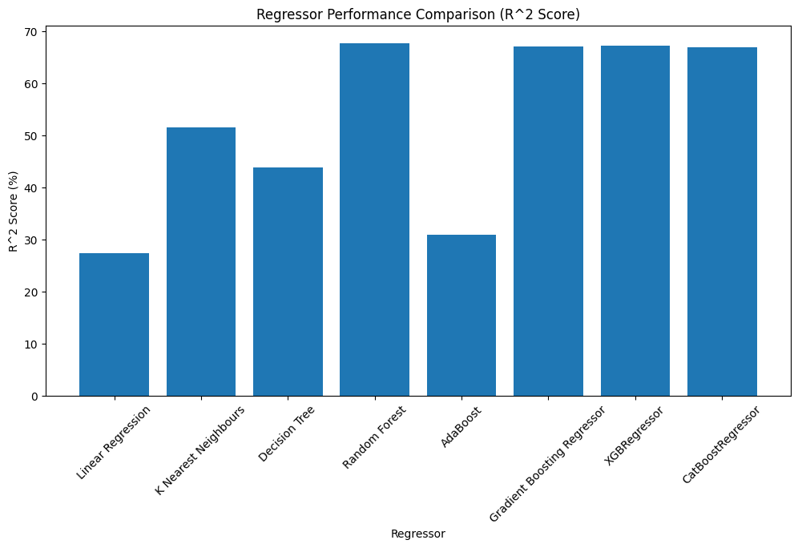

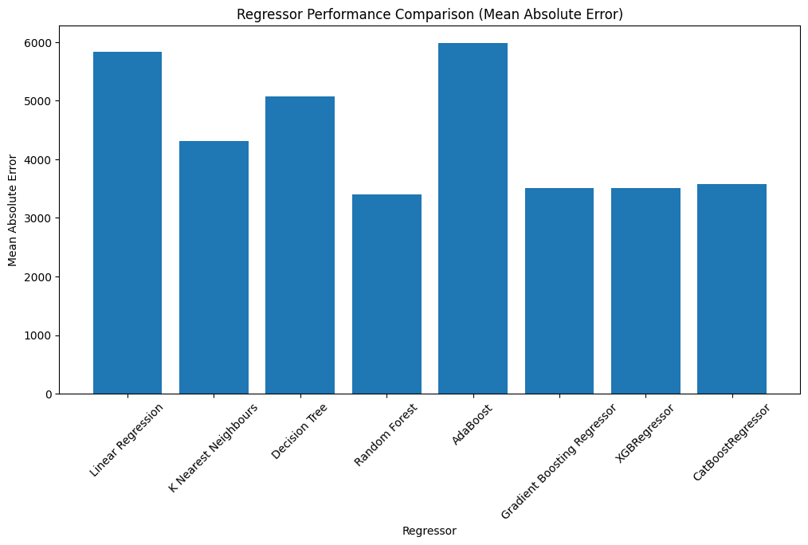

```python
from sklearn.preprocessing import StandardScaler, LabelEncoder, StandardScaler, PolynomialFeatures, MinMaxScaler
from sklearn.model_selection import train_test_split
from sklearn.linear_model import LinearRegression, Ridge, Lasso
from sklearn.neighbors import KNeighborsRegressor
from sklearn.ensemble import AdaBoostRegressor
from sklearn.ensemble import GradientBoostingRegressor
from sklearn.tree import DecisionTreeRegressor
from sklearn.ensemble import RandomForestRegressor
from xgboost import XGBRegressor
from catboost import CatBoostRegressor
from sklearn.metrics import r2_score, mean_absolute_error
import matplotlib.pyplot as plt

# Drop the price column from the data and store it in a separate variable
x = data.drop(['Price'], axis=1).values
# Store the target variable in a separate variable
y = data['Price'].values
# Scale the data
x = MinMaxScaler().fit_transform(x)

# We want to split the data into training and testing data
x_train, x_test, y_train, y_test = train_test_split(x, y, test_size=0.25, random_state=5)

# Regressor models
lr  = LinearRegression()
knn = KNeighborsRegressor(n_neighbors=8)
dt  = DecisionTreeRegressor(max_depth = 5)
rf  = RandomForestRegressor(n_estimators=100, max_features= 7)
ada = AdaBoostRegressor( n_estimators=150, learning_rate =.08)
gbr = GradientBoostingRegressor(max_depth=7, n_estimators=500, learning_rate =.05)
xgb = XGBRegressor(max_depth = 7, n_estimators=500, learning_rate =.05)
cb  = CatBoostRegressor(learning_rate =.07, max_depth =7, verbose=0)

regressors = [('Linear Regression', lr), ('K Nearest Neighbours', knn),('Decision Tree', dt), ('Random Forest', rf), ('AdaBoost', ada),('Gradient Boosting Regressor', gbr),('XGBRegressor', xgb),('CatBoostRegressor', cb)]

# Store the R^2 scores and mean absolute error for each regressor in lists
r2_scores = []
mae_scores = []

for regressor_name, regressor in regressors:
    regressor.fit(x_train, y_train)
    y_pred = regressor.predict(x_test)
    accuracy = round(r2_score(y_test, y_pred), 3) * 100
    r2_scores.append(accuracy)
    mae = mean_absolute_error(y_test, y_pred)
    mae_scores.append(mae)
    print('{:s} : {:.0f} %'.format(regressor_name, accuracy))

# Plot the R^2 scores in a bar chart
regressor_names = [r[0] for r in regressors]

plt.figure(figsize=(12, 6))
plt.bar(regressor_names, r2_scores)
plt.xlabel("Regressor")
plt.ylabel("R^2 Score (%)")
plt.title("Regressor Performance Comparison (R^2 Score)")
plt.xticks(rotation=45)
plt.show()

# Plot the mean absolute error in a bar chart
plt.figure(figsize=(12, 6))
plt.bar(regressor_names, mae_scores)
plt.xlabel("Regressor")
plt.ylabel("Mean Absolute Error")
plt.title("Regressor Performance Comparison (Mean Absolute Error)")
plt.xticks(rotation=45)
plt.show()
```

The Random Forest, Gradient Boosting, XGB, and CatBoost regressors seem to be the best among the ones tested, all achieving around 70% accuracy in predicting car prices. These models are ensemble-based, meaning that they rely on multiple weaker models to produce a more accurate overall prediction. Random Forest and Gradient Boosting, in particular, are well-suited for complex data sets with many features like this car price data, where traditional linear regression models may fall short. XGB and CatBoost are newer and more advanced ensemble-based models that are known for their high accuracy and ability to handle large datasets. Overall, these models are likely able to extract and use more information from the data, resulting in a better prediction.

On the other hand, the worst performers were Linear Regression with less than 30% accuracy and AdaBoost with around 30% accuracy. Linear Regression is a traditional method that is based on fitting a straight line to the data. While it is a simple and interpretable model, it may not capture the complexity of the data, especially in cases where there are many features. AdaBoost, while an ensemble-based model, relies on a decision tree as a weak learner. Decision trees can be prone to overfitting, especially when the data is complex, resulting in poor generalization performance. Overall, these models are less suited for this particular data set and may be better suited for simpler datasets or as a starting point for model selection.

### (0.6) Additional analysis (5000 level) You have free reign to provide any additional analyses.

In this example, we first split the data into training and testing sets. We then initialize two base models, Random Forest and Gradient Boosting, and train them on the training data. We make predictions using each model on the testing data, and combine the predictions into a 2D array. We then train a meta-model, in this case a Linear Regression model, on the combined predictions. Finally, we make predictions using the stacked model and calculate the R^2 score.

```python
from sklearn.ensemble import RandomForestRegressor, GradientBoostingRegressor
from sklearn.model_selection import train_test_split
from sklearn.metrics import r2_score
from sklearn.linear_model import LinearRegression

# Split the data into train and test sets
x_train, x_test, y_train, y_test = train_test_split(x, y, test_size=0.25, random_state=42)

# Initialize the models
rf = RandomForestRegressor(n_estimators=100, random_state=42)
gb = GradientBoostingRegressor(n_estimators=100, random_state=42)

# Train the models on the training data
rf.fit(x_train, y_train)
gb.fit(x_train, y_train)

# Make predictions using the models
rf_preds = rf.predict(x_test)
gb_preds = gb.predict(x_test)

# Combine the predictions into a 2D array
meta_X = np.column_stack((rf_preds, gb_preds))

# Train a meta-model on the combined predictions
lr = LinearRegression()
lr.fit(meta_X, y_test)

# Make predictions using the stacked model
stacked_preds = lr.predict(meta_X)

# Calculate the R^2 score of the stacked model
r2 = r2_score(y_test, stacked_preds)
print(f"R^2 Score of stacked model: {r2}")
```

```
R^2 Score of stacked model: 0.6653502751881554
```

Model stacking is a technique where the predictions made by several models are combined and used as input for a meta-model to produce a final prediction. In this code, the random forest and gradient boosting models are trained on the training data and used to make predictions on the test data. The predictions of both models are then combined into a 2D array and used as input to train a linear regression meta-model. The final prediction is made using the stacked model.